# Housing Subsidies in Emil City

Chris Michael

November 1st, 2022

# A. Introduction

### The Motivation for Analysis

This study is an initial step aimed towards assisting the Department of Housing and Community Development (HCD) of Emil City, in their approach to target home owners who qualify for a home repair tax credit program. The uptake of the home repair credit has been low, despite the efforts put in by the HCD to attract eligible home owners. This study aims to help streamline the department’s limited resources by converting all the client-level data collected from previous campaigns into a decision-making analytic, that can predict whether or not a homeowner will take up the housing subsidy. It is important to note that this study can be used as a primary base for further research, but cannot be used at this stage for policy and decision making.

# B. Set-Up

### I. Installing Packages

```r
library(tidyverse)
library(sf)
library(RSocrata)
library(viridis)
library(spatstat)
library(raster)
library(spdep)
library(FNN)
library(grid)
library(gridExtra)
library(RColorBrewer)
library(knitr)
library(kableExtra)
library(tidycensus)
library(classInt)
library(kableExtra)
library(RColorBrewer)
library(hrbrthemes)
library(ggthemes)
library(ggplot2)
library(plotly)
library(scales)
library(extrafont)
library(basetheme)
library(RColorBrewer)
library(lemon)
library(data.table)
library(GGally)
require(gridExtra)
library(ggalt)
library(rgeos)
library(sp)
library(smoothr)
library(rgdal)
library(rgeos)
library(maptools)
library(ggmap)
library(scales)
library(ggeasy)
library("wesanderson")
library(spdep)
library(caret)
library(ckanr)
library(FNN)
library(grid)
library(ggcorrplot)
library(corrr)
library(kableExtra)
library(jtools)
library(ggstance)
library(ggpubr)
library(broom.mixed)
library(tab)
library(sjPlot)
library(plotly)
library(stargazer)
library(pscl)
library(plotROC)
library(pROC)
library(lubridate)

col <- wes_palette("Cavalcanti1")
col5 <- colorRampPalette(col)(5)
col6 <- colorRampPalette(col)(6)
col7 <- colorRampPalette(col)(7)
col8 <- colorRampPalette(col)(8)
col10 <- colorRampPalette(col)(10)
col22 <- colorRampPalette(col)(22)
col29 <- colorRampPalette(col)(29)
col96 <- colorRampPalette(col)(96)

options(scipen = 999)
options(tigris_class = "sf")

root.dir = "https://raw.githubusercontent.com/urbanSpatial/Public-Policy-Analytics-Landing/master/DATA/"
```

I started creating the markdown by installing the required packages and loading them into the library. Some of the mainly used packages are `tidyverse`, `tidycensus`, and `dplyr`. The final deliverable for this homework is an RMarkdown file with the required plots and tables, knitted to a HTML document.

# C. Emil City Data

### I. Exploring the Housing Data

Here are some average characteristics of homeowners who are eligible to take the tax credit program from the Department of Housing and Community Development (HCD) of Emil City. This section visualizes predictive features by dividing it into continuous and categorical variables. Some of the variables of interest were the age of homeowners, their employment status and type of employment, as well as their marital status.

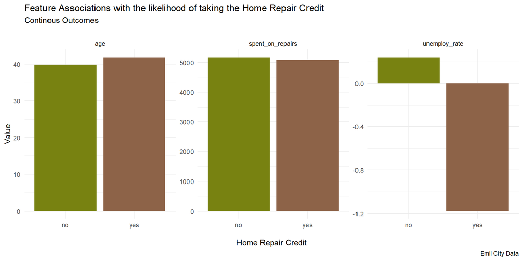

```r
housing <- read.csv("C:/Users/Chris Michael/Desktop/UPenn/Fall 2022/508/MUSA_508_Lab-main/MUSA_508_Lab-main/Week_7/housingSubsidy.csv")

housing %>%
  dplyr::select(y,age,unemploy_rate,spent_on_repairs) %>%
  gather(Variable, value, -y) %>%
    ggplot(aes(y, value, fill=y)) +
      geom_bar(position = "dodge", stat = "summary", fun = "mean") +
      facet_wrap(~Variable, scales = "free") +
      scale_fill_manual(values = c("#788211","#8d6348")) +
      labs(x="\nHome Repair Credit", y="Value",
           title = "Feature Associations with the likelihood of taking the Home Repair Credit",
           subtitle = "Continous Outcomes\n",
           caption = "Emil City Data") +
      theme_minimal()+theme(legend.position = "none")
```

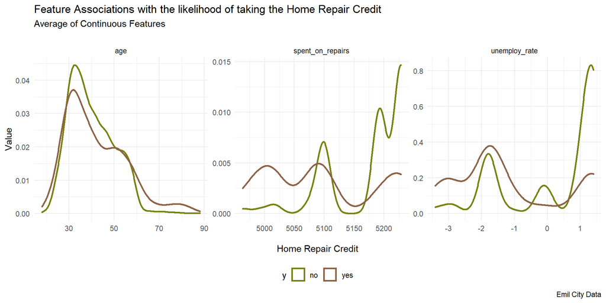

```r
housing %>% dplyr::select(y,age,unemploy_rate,spent_on_repairs) %>%
  gather(Variable, value, -y) %>%
     ggplot() +
    geom_density(aes(value, color=y), size=1) +
    facet_wrap(~Variable, scales = "free") +
    scale_color_manual(values = c("#788211","#8d6348")) +
      labs(x="\nHome Repair Credit", y="Value",
           title = "Feature Associations with the likelihood of taking the Home Repair Credit",
           subtitle = "Average of Continuous Features\n",
           caption = "Emil City Data") +
      theme_minimal()+theme(legend.position = "bottom")
```

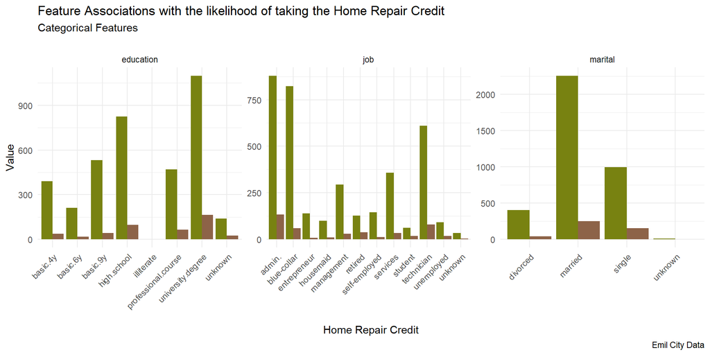

```r
housing %>%
    dplyr::select(y, job, marital, education) %>%
    gather(Variable, value, -y) %>%
    count(Variable, value, y) %>%
      ggplot(., aes(value, n, fill = y)) +
        geom_bar(position = "dodge", stat="identity") +
        facet_wrap(~Variable, scales="free") +
        scale_fill_manual(values = c("#788211","#8d6348")) +
      labs(x="\nHome Repair Credit", y="Value",
           title = "Feature Associations with the likelihood of taking the Home Repair Credit",
           subtitle = "Categorical Features\n",
           caption = "Emil City Data") +
      theme_minimal() + theme(legend.position = "none")+
        theme(axis.text.x = element_text(angle = 45, hjust = 1))
```

### II. Feature Engineering

In order to develop a model to predict likelihood of taking home repair credit, I feature engineered a few variables from the initial table that were likely to increase the accuracy of my model. Some of the new variables were employment status, educational status and marital status.

```r
housing <- housing %>%
  mutate(EmploymentStatus = case_when(job == "student" | job == "unemployed" |
                                        job == "retired" ~ "unemployed",
                                      TRUE  ~ "employed")) %>%
  mutate(MaritalStatus = case_when(marital == "single" | marital == "divorced"|
                                     marital == "unknown" ~ "unmarried",
                                   TRUE ~ "married")) %>%
  mutate(EducationStatus = case_when(education == "illiterate" |
                                       education == "unknown" ~ "illiterate",
                                     education == "basic.4y" |
                                       education == "basic.6y" |
                                       education == "basic.9y" |
                                       education == "high.school" ~
                                       "high school",
                                     TRUE ~ "university")) %>%
  mutate(Tax = case_when(taxLien == "no" | taxLien == "unknown" ~ "no",
                         TRUE ~ "yes"))
```

# D. Statistical Modeling

### I. Binomial Logit Regression Models

For this section, I created two datasets:

- The dataset with the feature engineered variables
- The kitchen sink dataset with just the initial set of variables

This is where we first start to see differences between the two datasets. After running the logit regression, **the model with the engineer variables had a McFadden R-squared value of 0.22**. However, **the kitchen sink model had a McFadden R-squared value of 0.23**, which is slightly higher that the engineered model. Any additions of both engineered variables or additional variables from the dataset seemed to further worsen the model.

```r
set.seed(3456)
trainIndex <- createDataPartition(housing$y_numeric, p = .65,
                                  list = FALSE,
                                  times = 1)

housingTrain <- housing[ trainIndex,]
housingTest  <- housing[-trainIndex,]

housing_model1 <- glm(y_numeric ~ .,
                  data=housingTrain %>%
                    dplyr::select(-y, -marital, -X,
                                  -education, -taxLien),
                  family="binomial" (link="logit"))

Kable_1 <- pR2(housing_model1)


set.seed(3456)
trainIndex_ks <- createDataPartition(housing$y_numeric, p = .65,
                                  list = FALSE,
                                  times = 1)

housingTrain_ks <- housing[ trainIndex,]
housingTest_ks  <- housing[-trainIndex,]


housing_model2 <- glm(y_numeric ~ .,
                  data=housingTrain_ks %>%
                    dplyr::select(-EmploymentStatus, -MaritalStatus,
                                  -EducationStatus, -Tax, -y, -X),
                  family="binomial" (link="logit"))

Kable_2 <-pR2(housing_model2)
```

The two tables below details out the results of computing the pseudo r-squared for both the engineered model and the kitchen sink model.

```r
Kable_1 %>% kable(caption = "Regression Summary: Engineered Model") %>% kable_styling()
```

Regression Summary: Engineered Model

|  | x |
| --- | --- |
| llh | -733.0461739 |
| llhNull | -949.5486289 |
| G2 | 433.0049100 |
| McFadden | 0.2280057 |
| r2ML | 0.1492948 |
| r2CU | 0.2939242 |

```r
Kable_2 %>% kable(caption = "Regression Summary: Kitchen Sink Model") %>% kable_styling()
```

Regression Summary: Kitchen Sink Model

|  | x |
| --- | --- |
| llh | -730.7496684 |
| llhNull | -949.5486289 |
| G2 | 437.5979211 |
| McFadden | 0.2304242 |
| r2ML | 0.1507526 |
| r2CU | 0.2967942 |

The summaries of both binomial logit regressions are given below. The `stargazer` package was used to produce this output.

```r
stargazer(housing_model1, type = "html", style = "aer",
          dep.var.labels=c("Likelihood of Taking the Home Repair Credit"),
          title="Results of Logit Regression: Engineered Model",
          single.row = TRUE,
          notes.label = 'Notes',
          notes = 'Regression model created on the training dataset. The model was selected based on the AIC and model sensitivity',
          notes.align = 'l')
```

**Results of Logit Regression: Engineered Model**

|  | Likelihood of Taking the Home Repair Credit |
| --- | --- |
| age | 0.020** (0.008) |
| jobblue-collar | -0.470** (0.226) |
| jobentrepreneur | -0.386 (0.444) |
| jobhousemaid | -0.627 (0.490) |
| jobmanagement | -0.300 (0.296) |
| jobretired | -0.478 (0.358) |
| jobself-employed | -1.112** (0.503) |
| jobservices | -0.379 (0.281) |
| jobstudent | -0.195 (0.410) |
| jobtechnician | -0.059 (0.210) |
| jobunemployed | 0.044 (0.414) |
| jobunknown | -0.698 (0.751) |
| mortgageunknown | -0.090 (0.512) |
| mortgageyes | -0.096 (0.144) |
| taxbill_in_phlyes | 0.095 (0.197) |
| contacttelephone | -1.129*** (0.291) |
| monthaug | -0.396 (0.448) |
| monthdec | 0.277 (0.746) |
| monthjul | -0.045 (0.363) |
| monthjun | 0.267 (0.452) |
| monthmar | 0.968* (0.572) |
| monthmay | -0.587* (0.304) |
| monthnov | -0.409 (0.419) |
| monthoct | -0.550 (0.566) |
| monthsep | -0.745 (0.651) |
| day_of_weekmon | -0.009 (0.222) |
| day_of_weekthu | 0.019 (0.223) |
| day_of_weektue | -0.001 (0.229) |
| day_of_weekwed | 0.096 (0.233) |
| campaign | -0.068* (0.040) |
| pdays | 0.000 (0.001) |
| previous | 0.573** (0.229) |
| poutcomenonexistent | 1.263*** (0.367) |
| poutcomesuccess | 1.699** (0.784) |
| unemploy_rate | -0.601 (0.506) |
| cons.price.idx | 1.123 (0.878) |
| cons.conf.idx | 0.053* (0.029) |
| inflation_rate | -0.058 (0.458) |
| spent_on_repairs | -0.001 (0.011) |
| EmploymentStatusunemployed |  |
| MaritalStatusunmarried | 0.047 (0.154) |
| Constant | -103.516 (132.300) |
| Observations | 2,678 |
| Log Likelihood | -733.046 |
| Akaike Inf. Crit. | 1,548.092 |
| Notes | ***Significant at the 1 percent level. |
|  | **Significant at the 5 percent level. |
|  | *Significant at the 10 percent level. |
|  | Regression model created on the training dataset. The model was selected based on the AIC and model sensitivity |

```r
stargazer(housing_model2, type = "html", style = "aer",
          dep.var.labels=c("Likelihood of Taking the Home Repair Credit"),
          title="Results of Logit Regression: Kitchen Sink Model",
          single.row = TRUE,
          notes.label = 'Notes',
          notes = 'Regression model created on the training dataset. The model was selected based on the AIC and model sensitivity',
          notes.align = 'l')
```

**Results of Logit Regression: Kitchen Sink Model**

|  | Likelihood of Taking the Home Repair Credit |
| --- | --- |
| age | 0.025*** (0.008) |
| jobblue-collar | -0.371 (0.272) |
| jobentrepreneur | -0.331 (0.446) |
| jobhousemaid | -0.506 (0.509) |
| jobmanagement | -0.287 (0.299) |
| jobretired | -0.414 (0.369) |
| jobself-employed | -1.110** (0.504) |
| jobservices | -0.313 (0.295) |
| jobstudent | -0.229 (0.433) |
| jobtechnician | -0.038 (0.229) |
| jobunemployed | 0.101 (0.424) |
| jobunknown | -0.721 (0.760) |
| maritalmarried | 0.301 (0.258) |
| maritalsingle | 0.514* (0.294) |
| maritalunknown | 0.334 (1.291) |
| educationbasic.6y | 0.102 (0.423) |
| educationbasic.9y | 0.175 (0.333) |
| educationhigh.school | 0.165 (0.316) |
| educationilliterate | -11.686 (535.411) |
| educationprofessional.course | 0.172 (0.353) |
| educationuniversity.degree | 0.239 (0.321) |
| educationunknown | 0.263 (0.431) |
| taxLienunknown | -0.060 (0.219) |
| taxLienyes | -10.388 (535.411) |
| mortgageunknown | -0.077 (0.517) |
| mortgageyes | -0.104 (0.145) |
| taxbill_in_phlyes | 0.108 (0.198) |
| contacttelephone | -1.134*** (0.292) |
| monthaug | -0.394 (0.449) |
| monthdec | 0.246 (0.754) |
| monthjul | -0.051 (0.364) |
| monthjun | 0.236 (0.455) |
| monthmar | 0.988* (0.576) |
| monthmay | -0.566* (0.306) |
| monthnov | -0.408 (0.422) |
| monthoct | -0.553 (0.569) |
| monthsep | -0.729 (0.653) |
| day_of_weekmon | 0.005 (0.223) |
| day_of_weekthu | 0.031 (0.224) |
| day_of_weektue | 0.034 (0.231) |
| day_of_weekwed | 0.130 (0.233) |
| campaign | -0.068* (0.040) |
| pdays | 0.000 (0.001) |
| previous | 0.555** (0.229) |
| poutcomenonexistent | 1.232*** (0.367) |
| poutcomesuccess | 1.705** (0.785) |
| unemploy_rate | -0.630 (0.507) |
| cons.price.idx | 1.175 (0.883) |
| cons.conf.idx | 0.054* (0.029) |
| inflation_rate | -0.062 (0.461) |
| spent_on_repairs | 0.000 (0.011) |
| Constant | -112.898 (133.020) |
| Observations | 2,678 |
| Log Likelihood | -730.750 |
| Akaike Inf. Crit. | 1,565.499 |
| Notes | ***Significant at the 1 percent level. |
|  | **Significant at the 5 percent level. |
|  | *Significant at the 10 percent level. |
|  | Regression model created on the training dataset. The model was selected based on the AIC and model sensitivity |

### II. Making Predictions

From the density plots below, we can say that both the model with engineered features as well as the kitchen sink model, predict true negatives well; i.e, the number of people who do not take the credit. However, both models predict poorly for the true positives or the number of people that actually take the housing repair tax credit. These models can be bettered using additional variables like income, rent and poverty rates in the area.

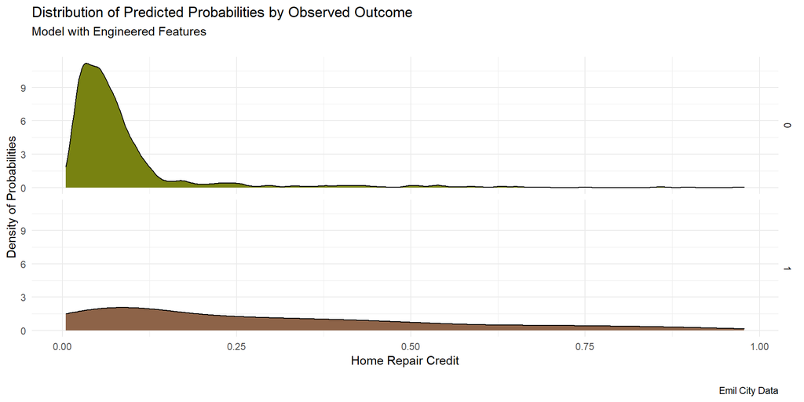

```r
testProbs <- data.frame(Outcome = as.factor(housingTest$y_numeric),
                        Probs = predict(housing_model1, housingTest, type= "response"))

ggplot(testProbs, aes(x = Probs, fill = as.factor(Outcome))) +
  geom_density() +
  facet_grid(Outcome ~ .) +
  scale_fill_manual(values = c("#788211","#8d6348")) +
  labs(x = "Home Repair Credit\n", y = "Density of Probabilities",
       title = "Distribution of Predicted Probabilities by Observed Outcome",
       subtitle = "Model with Engineered Features\n",
           caption = "Emil City Data") +
      theme_minimal() + theme(legend.position = "none")
```

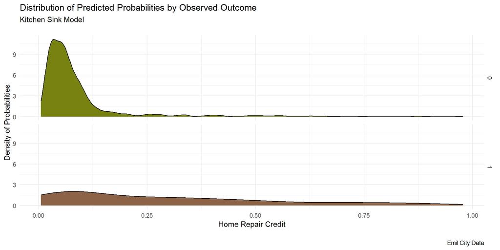

```r
testProbs_ks <- data.frame(Outcome = as.factor(housingTest_ks$y_numeric),
                        Probs = predict(housing_model2, housingTest, type= "response"))

ggplot(testProbs_ks, aes(x = Probs, fill = as.factor(Outcome))) +
  geom_density() +
  facet_grid(Outcome ~ .) +
  scale_fill_manual(values = c("#788211","#8d6348")) +
  labs(x = "Home Repair Credit\n", y = "Density of Probabilities",
       title = "Distribution of Predicted Probabilities by Observed Outcome",
       subtitle = "Kitchen Sink Model\n",
           caption = "Emil City Data") +
      theme_minimal() + theme(legend.position = "none")
```

### III. Confusion Matrix

The confusion matrices below show the slight differences between the kitchen sink model and the engineered model. Despite similar sensitivity and specificity values, the engineered model predicts one less true negative that the kitchen sink model. It also predicts true positives slightly worse than the kitchen sink model. In the 50% threshold, the engineered model predicts 27 occurrences of homeowners taking the housing repair credit, whereas the kitchen sink model predicts 29.

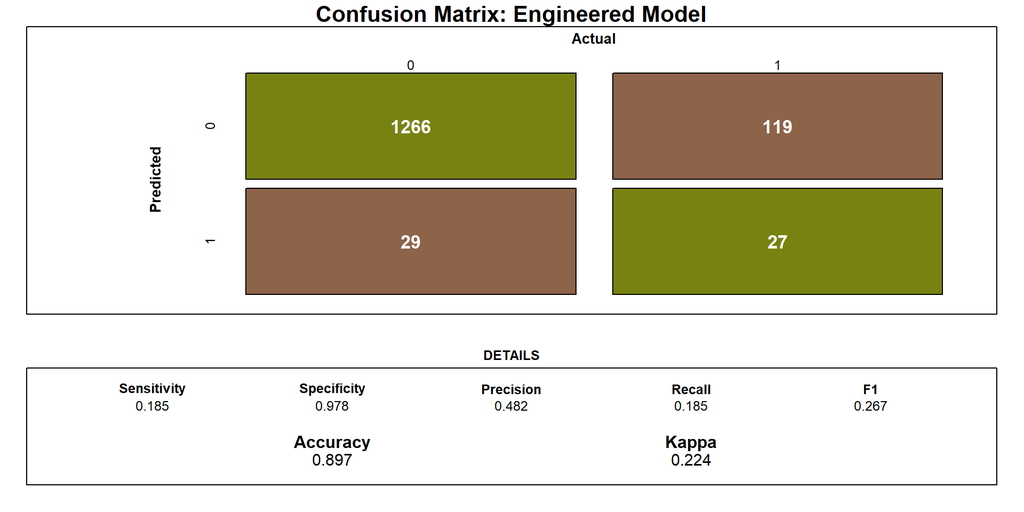

```r
testProbs <-
  testProbs %>%
  mutate(predOutcome  = as.factor(ifelse(testProbs$Probs > 0.5 , 1, 0)))

cm <- confusionMatrix(testProbs$predOutcome, testProbs$Outcome,
                       positive = "1")

draw_confusion_matrix <- function(cm) {

  layout(matrix(c(1,1,2)))
  par(mar=c(2,2,2,2))
  plot(c(100, 345), c(300, 450), type = "n", xlab="", ylab="", xaxt='n', yaxt='n')
  title('Confusion Matrix: Engineered Model', cex.main=2)

  # create the matrix
  rect(150, 430, 240, 370, col='#788211')
  text(195, 435, '0', cex=1.2)
  rect(250, 430, 340, 370, col='#8d634a')
  text(295, 435, '1', cex=1.2)
  text(125, 370, 'Predicted', cex=1.3, srt=90, font=2)
  text(245, 450, 'Actual', cex=1.3, font=2)
  rect(150, 305, 240, 365, col='#8d634a')
  rect(250, 305, 340, 365, col='#788211')
  text(140, 400, '0', cex=1.2, srt=90)
  text(140, 335, '1', cex=1.2, srt=90)

  # add in the cm results
  res <- as.numeric(cm$table)
  text(195, 400, res[1], cex=1.6, font=2, col='white')
  text(195, 335, res[2], cex=1.6, font=2, col='white')
  text(295, 400, res[3], cex=1.6, font=2, col='white')
  text(295, 335, res[4], cex=1.6, font=2, col='white')

  # add in the specifics
  plot(c(100, 0), c(100, 0), type = "n", xlab="", ylab="", main = "DETAILS", xaxt='n', yaxt='n')
  text(10, 85, names(cm$byClass[1]), cex=1.2, font=2)
  text(10, 70, round(as.numeric(cm$byClass[1]), 3), cex=1.2)
  text(30, 85, names(cm$byClass[2]), cex=1.2, font=2)
  text(30, 70, round(as.numeric(cm$byClass[2]), 3), cex=1.2)
  text(50, 85, names(cm$byClass[5]), cex=1.2, font=2)
  text(50, 70, round(as.numeric(cm$byClass[5]), 3), cex=1.2)
  text(70, 85, names(cm$byClass[6]), cex=1.2, font=2)
  text(70, 70, round(as.numeric(cm$byClass[6]), 3), cex=1.2)
  text(90, 85, names(cm$byClass[7]), cex=1.2, font=2)
  text(90, 70, round(as.numeric(cm$byClass[7]), 3), cex=1.2)

  # add in the accuracy information
  text(30, 35, names(cm$overall[1]), cex=1.5, font=2)
  text(30, 20, round(as.numeric(cm$overall[1]), 3), cex=1.4)
  text(70, 35, names(cm$overall[2]), cex=1.5, font=2)
  text(70, 20, round(as.numeric(cm$overall[2]), 3), cex=1.4)
}

draw_confusion_matrix(cm)
```

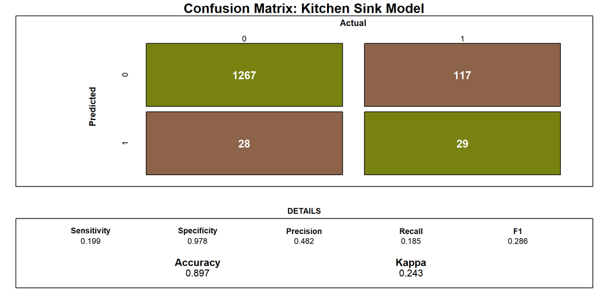

```r
testProbs_ks <-
  testProbs_ks %>%
  mutate(predOutcome  = as.factor(ifelse(testProbs_ks$Probs > 0.5 , 1, 0)))

cm_ks <- confusionMatrix(testProbs_ks$predOutcome, testProbs_ks$Outcome,
                       positive = "1")

draw_confusion_matrix <- function(cm_ks) {

  layout(matrix(c(1,1,2)))
  par(mar=c(2,2,2,2))
  plot(c(100, 345), c(300, 450), type = "n", xlab="", ylab="", xaxt='n', yaxt='n')
  title('Confusion Matrix: Kitchen Sink Model', cex.main=2)

  # create the matrix
  rect(150, 430, 240, 370, col='#788211')
  text(195, 435, '0', cex=1.2)
  rect(250, 430, 340, 370, col='#8d634a')
  text(295, 435, '1', cex=1.2)
  text(125, 370, 'Predicted', cex=1.3, srt=90, font=2)
  text(245, 450, 'Actual', cex=1.3, font=2)
  rect(150, 305, 240, 365, col='#8d634a')
  rect(250, 305, 340, 365, col='#788211')
  text(140, 400, '0', cex=1.2, srt=90)
  text(140, 335, '1', cex=1.2, srt=90)

  # add in the cm results
  res <- as.numeric(cm_ks$table)
  text(195, 400, res[1], cex=1.6, font=2, col='white')
  text(195, 335, res[2], cex=1.6, font=2, col='white')
  text(295, 400, res[3], cex=1.6, font=2, col='white')
  text(295, 335, res[4], cex=1.6, font=2, col='white')

  # add in the specifics
  plot(c(100, 0), c(100, 0), type = "n", xlab="", ylab="", main = "DETAILS", xaxt='n', yaxt='n')
  text(10, 85, names(cm_ks$byClass[1]), cex=1.2, font=2)
  text(10, 70, round(as.numeric(cm_ks$byClass[1]), 3), cex=1.2)
  text(30, 85, names(cm_ks$byClass[2]), cex=1.2, font=2)
  text(30, 70, round(as.numeric(cm$byClass[2]), 3), cex=1.2)
  text(50, 85, names(cm_ks$byClass[5]), cex=1.2, font=2)
  text(50, 70, round(as.numeric(cm$byClass[5]), 3), cex=1.2)
  text(70, 85, names(cm_ks$byClass[6]), cex=1.2, font=2)
  text(70, 70, round(as.numeric(cm$byClass[6]), 3), cex=1.2)
  text(90, 85, names(cm_ks$byClass[7]), cex=1.2, font=2)
  text(90, 70, round(as.numeric(cm_ks$byClass[7]), 3), cex=1.2)

  # add in the accuracy information
  text(30, 35, names(cm_ks$overall[1]), cex=1.5, font=2)
  text(30, 20, round(as.numeric(cm$overall[1]), 3), cex=1.4)
  text(70, 35, names(cm_ks$overall[2]), cex=1.5, font=2)
  text(70, 20, round(as.numeric(cm_ks$overall[2]), 3), cex=1.4)
}

draw_confusion_matrix(cm_ks)
```

### IV. ROC Curve

The ROC curve helps us understand the goodness of fit of a model and the area under the curve (AUC) is a direct measurement of the curve. For the model with **engineered variables, the area under the curve is 0.78**, whereas for the **kitchen sink model it is 0.77**. For the engineered model, 0.78 represents the probability of getting a positive where there was a true positive. From the graphs, it can be observed that while the model predicts correctly 75% of the time, the model will also predict incorrectly 25% of the time, which is not a negligible number.

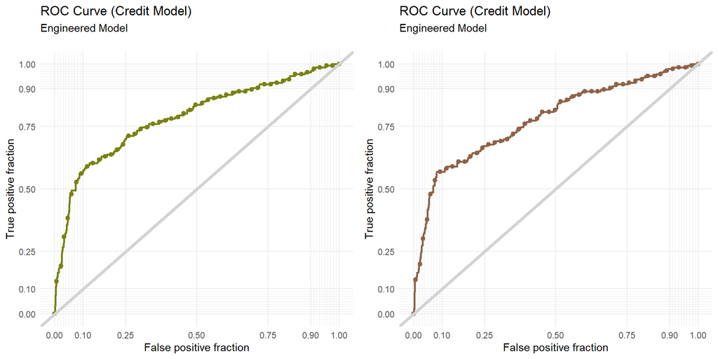

```r
auc(testProbs$Outcome, testProbs$Probs)

A <- ggplot(testProbs, aes(d = as.numeric(Outcome), m = Probs)) +
  geom_roc(n.cuts = 50, labels = FALSE, colour = "#788211") +
  style_roc() +
  geom_abline(slope = 1, intercept = 0, size = 1.5, color = 'lightgrey') +
  labs(title = "ROC Curve (Credit Model)",
       subtitle = "Engineered Model\n") +
  theme_minimal()

auc(testProbs_ks$Outcome, testProbs_ks$Probs)

B <- ggplot(testProbs_ks, aes(d = as.numeric(Outcome), m = Probs)) +
  geom_roc(n.cuts = 50, labels = FALSE, colour = "#8d6348") +
  style_roc() +
  geom_abline(slope = 1, intercept = 0, size = 1.5, color = 'lightgrey') +
  labs(title = "ROC Curve (Credit Model)",
       subtitle = "Engineered Model\n") +
  theme_minimal()

ggarrange(A,B, align="v")
```

# E. Cross Validation

### I. Cross Validation & Generalizability

To understand generalizability, we run 100-fold cross validation and look at the ROC (aka AUC), Sensitivity and Specificity across this series of predictions. From the set of plots below, we can see that both the model with engineered features as well as the kitchen sink model generalize well when it comes to sensitivity- predicting true positives. Both models however, do poorly when it comes to specificity- predicting true negatives.

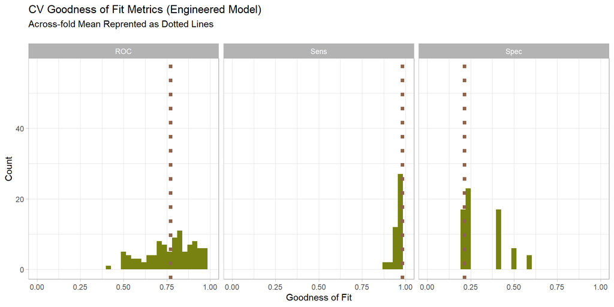

```r
ctrl <- trainControl(method = "cv", number = 100, classProbs=TRUE, summaryFunction=twoClassSummary)

cvFit <- train(y ~ .,
                  data=housing %>%
                    dplyr::select(-y_numeric, -EducationStatus, -marital, -X,
                                  -education, -Tax, -taxLien),
                method="glm", family="binomial",
                metric="ROC", trControl = ctrl)

cvFit

dplyr::select(cvFit$resample, -Resample) %>%
  gather(metric, value) %>%
  left_join(gather(cvFit$results[2:4], metric, mean)) %>%
  ggplot(aes(value)) +
    geom_histogram(bins=35, fill = "#788211") +
    facet_wrap(~metric) +
    geom_vline(aes(xintercept = mean), colour = "#8d634a", linetype = 3, size = 2) +
    scale_x_continuous(limits = c(0, 1)) +
    labs(x="Goodness of Fit", y="Count", title="CV Goodness of Fit Metrics (Engineered Model)",
         subtitle = "Across-fold Mean Reprented as Dotted Lines\n")+
  theme_light()
```

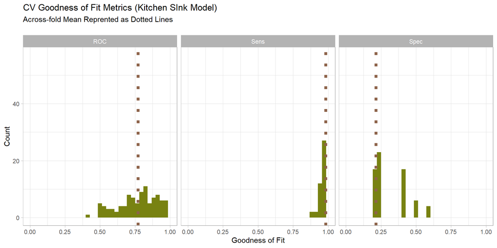

```r
cvFit_ks <- train(y ~ .,
                  data=housing %>%
                    dplyr::select(-EmploymentStatus, -MaritalStatus,
                                  -EducationStatus, -Tax, -y_numeric, -X),
                method="glm", family="binomial",
                metric="ROC", trControl = ctrl)

cvFit_ks

dplyr::select(cvFit$resample, -Resample) %>%
  gather(metric, value) %>%
  left_join(gather(cvFit$results[2:4], metric, mean)) %>%
  ggplot(aes(value)) +
    geom_histogram(bins=35, fill = "#788211") +
    facet_wrap(~metric) +
    geom_vline(aes(xintercept = mean), colour = "#8d634a", linetype = 3, size = 2) +
    scale_x_continuous(limits = c(0, 1)) +
    labs(x="Goodness of Fit", y="Count", title="CV Goodness of Fit Metrics (Kitchen SInk Model)",
         subtitle = "Across-fold Mean Reprented as Dotted Lines\n")+
  theme_light()
```

# F. Cost Benefit Analysis

### I. Calculations

Here are some of the given facts that will help guide the cost/benefit analysis in the upcoming sections.

- If it is predicted that a householder will take the credit, then HCD allocates **$2,850** per homeowner which includes staff and resources to facilitate mailers, phone calls, and information/counseling sessions at the HCD offices.
- We should now assume **25% of contacted eligible homeowners receive the credit**. The remaining 75% that receive the marketing allocation and enter the program do not take the credit for various reasons.
- The **credit allocates $5,000 per homeowner** which can be used toward home improvement.
- Homes surrounding the repaired home see an **aggregate premium of $56,000**, on average.

Therefore, the cost/benefit analysis is conducted as follows:

- True Negative: Predicted correctly homeowner would not take the credit, no marketing resources were allocated, and no credit was allocated *TN = 0*
- True Positive: Predicted correctly homeowner would take the credit, marketing resources were allocated, and 25% took the credit *TP = ((58150 x Count)*0.25)*
- False Negative: Predicted that a homeowner would not take the credit but they did *FN = 0*
- False Positive: Predicted incorrectly homeowner would take the credit, allocated marketing resources; no credit allocated *Count(-2850)*

The cost/benefit table is given below.

```r
cost_benefit_table <-
   testProbs %>%
      count(predOutcome, Outcome) %>%
      summarize(True_Negative = sum(n[predOutcome==0 & Outcome==0]),
                True_Positive = sum(n[predOutcome==1 & Outcome==1]),
                False_Negative = sum(n[predOutcome==0 & Outcome==1]),
                False_Positive = sum(n[predOutcome==1 & Outcome==0])) %>%
       gather(Variable, Count) %>%
       mutate(Revenue =
                case_when(Variable == "True_Negative" ~ Count * 0,
               Variable == "True_Positive" ~ (58150 * Count)*0.25,
               Variable == "False_Negative" ~ ( Count * 0),
               Variable == "False_Positive" ~ (-2850) * Count)) %>%
    bind_cols(data.frame(Description = c(
              "Predicted correctly homeowner would not take the credit, no marketing resources were allocated, and no credit was allocated",
              "Predicted correctly homeowner would take the credit, marketing resources were allocated, and 25% took the credit",
              "Predicted that a homeowner would not take the credit but they did",
              "Predicted incorrectly homeowner would take the credit, allocated marketing resources; no credit allocated")))

kable(cost_benefit_table,
       caption = "Cost/Benefit Table") %>% kable_styling()
```

Cost/Benefit Table

| Variable | Count | Revenue | Description |
| --- | --- | --- | --- |
| True_Negative | 1266 | 0.0 | Predicted correctly homeowner would not take the credit, no marketing resources were allocated, and no credit was allocated |
| True_Positive | 27 | 392512.5 | Predicted correctly homeowner would take the credit, marketing resources were allocated, and 25% took the credit |
| False_Negative | 119 | 0.0 | Predicted that a homeowner would not take the credit but they did |
| False_Positive | 29 | -82650.0 | Predicted incorrectly homeowner would take the credit, allocated marketing resources; no credit allocated |

### II. Optimizing the Cost/Benefit Relationships

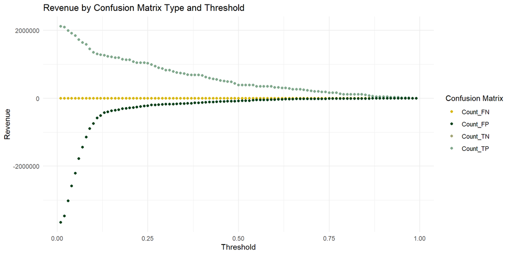

```r
whichThreshold <-
  iterateThresholds(
     data=testProbs, observedClass = Outcome, predictedProbs = Probs)

whichThreshold <-
  whichThreshold %>%
    dplyr::select(starts_with("Count"), Threshold) %>%
    gather(Variable, Count, -Threshold) %>%
    mutate(Revenue =
             case_when(Variable == "Count_TN"  ~ Count * 0,
                       Variable == "Count_TP"  ~ (58150 * Count)*0.25,
                       Variable == "Count_FN"  ~ (0) * Count,
                       Variable == "Count_FP"  ~ (-2850) * Count))
whichThreshold %>%
  ggplot(.,aes(Threshold, Revenue, colour = Variable)) +
  geom_point() +
  scale_colour_manual(values = col5) +
  labs(title = "Revenue by Confusion Matrix Type and Threshold",
       y = "Revenue") +
  theme_minimal() +
  guides(colour=guide_legend(title = "Confusion Matrix"))
```

### III. Visualizers for Threshold

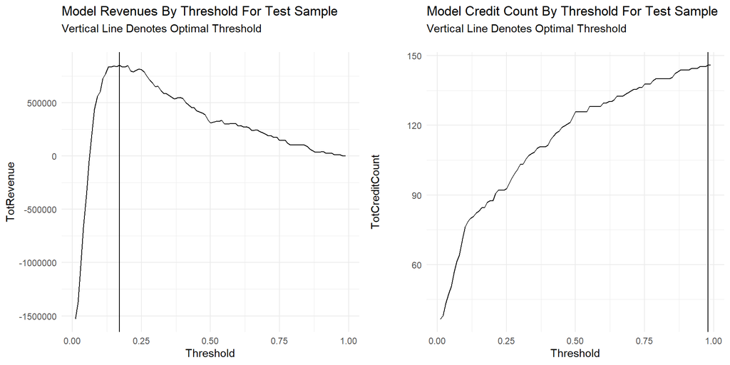

```r
whichThreshold_v<-
  whichThreshold %>%
    mutate(TookCredit = ifelse(Variable == "Count_TP", (Count * .25),
                         ifelse(Variable == "Count_FN", Count, 0))) %>%
  group_by(Threshold) %>%
    summarize(TotRevenue = sum(Revenue),
              TotCreditCount = sum(TookCredit))

C <- ggplot(whichThreshold_v)+
  geom_line(aes(x = Threshold, y = TotRevenue))+
  geom_vline(xintercept =  pull(arrange(whichThreshold_v, -TotRevenue)[1,1]))+
    labs(title = "Model Revenues By Threshold For Test Sample",
         subtitle = "Vertical Line Denotes Optimal Threshold\n") +
  theme_minimal()

D <- ggplot(whichThreshold_v)+
  geom_line(aes(x = Threshold, y = TotCreditCount))+
  geom_vline(xintercept =  pull(arrange(whichThreshold_v, -TotCreditCount)[1,1]))+
    labs(title = "Model Credit Count By Threshold For Test Sample",
         subtitle = "Vertical Line Denotes Optimal Threshold\n")+
  theme_minimal()

ggarrange(C,D, align = "v")
```

```r
optimalthreshold <-
  whichThreshold_v %>%
  dplyr::select(Threshold, TotRevenue, TotCreditCount)

optimalthreshold <- optimalthreshold %>%
  filter(row(optimalthreshold) == c(25, 50))

kable(optimalthreshold,
       caption = "Revenue and Credit Table for Thresholds") %>% kable_styling()
```

Revenue and Credit Table for Thresholds

| Threshold | TotRevenue | TotCreditCount |
| --- | --- | --- |
| 0.25 | 812712.5 | 92.75 |
| 0.50 | 309862.5 | 125.75 |

# G. Conclusion

From this study, it is clear that neither the neither the kitchen sink model nor the engineered model are fit to be used in a real world context just yet. Both due to the low McFadden R-squared statistic, low generalizability and low specificity, the model definitely needs some rigorous work as well as addition of new variables. When looking at homeowners who are eligible to receive the home repair tax credit, variables like income, rent, and what percent of income goes into rent and other housing related costs could be significant. Other variables of interest could include number of householders, place of work, if the household is already recieving subsidies from the government.